# Weissman-replication-analysis

Marton Kovacs

10 November, 2020

# Load packages

```r
if (!require("pacman")) install.packages("pacman")
pacman::p_load(tidyverse, osfr, lme4, BayesFactor, DescTools, sjstats, car, broom, papaja, cowplot)
```

# Load helper functions

```r
source("utils.R")
```

# Download data from OSF

## OSF auth (until project is public)

Read/write token should be created on OSF and it should be named as “osf_token_write”

```r
# Let's not require OSF auth if we're not downloading any data
if (params$download_from_osf == "yes")
   osf_auth(token = read_lines(list.files(pattern ="osf_token_write_.*.txt")))
```

## Connect to data OSF folder

```r
data_guid <- "9knds"

weissman_project <- osf_retrieve_node(data_guid)
```

## Download data locally

```r
if(params$dataset == "main") {
  data_subdir <- "Processed_main"


} else if(params$dataset == "no_fst") {
   data_subdir <- "Processed_no_fst"

} else if(params$dataset == "no_scnd") {
  data_subdir <- "Processed_no_scnd"

} else if(params$dataset == "both") {
  data_subdir <- "Processed_both"

} else {
  stop("wrong parameter")
}

local_data_pth <- file.path("data",data_subdir)

# it is better to download data only if specified
if (params$download_from_osf == "yes") {
   create_local_structure(local_data_pth)

   data_files <-
      weissman_project %>%
      osf_ls_files() %>%
      filter(name == data_subdir) %>%
      osf_ls_files()

   data_files %>%
      group_by(name) %>% # for each experiment type
      do(download_files(.,local_data_pth))
}
# uncomment following line to remove the data
# remove_local_data(local_data_pth)
```

# Import data

```r
# Saving subfolder names
subfolder <- list("primeprobe", "flanker", "stroop", "simon")

# Reading data
processed <-
  tibble(task = subfolder,
         rt_data = map(subfolder,
                       ~ read_plus(subfolder_name = .x,
                                   pattern = ".tsv$",
                                   path = local_data_pth,
                                   sep = "\t",
                                   include = "_Rt_")),
         acc_data = map(subfolder,
                        ~ read_plus(subfolder_name = .x,
                                    pattern = ".tsv$",
                                    path = local_data_pth,
                                    sep = "\t",
                                    include = "_Acc_")),
         acc_exp_data = map(subfolder,
                        ~ read_plus(subfolder_name = .x,
                                    pattern = ".tsv$",
                                    path = local_data_pth,
                                    sep = "\t",
                                    include = "_Acc_Exploratory_")))

# Reading original study effect sizes
original <- read_tsv("original_study_data.tsv")
```

# Set task names

```r
processed$rt_data <- set_names(processed$rt_data, processed$task)

processed$acc_data <- set_names(processed$acc_data, processed$task)

processed$acc_exp_data <- set_names(processed$acc_exp_data, processed$task)
```

# Descriptive statistics of the sample size

## Number of participants left after exclusion

The number of participants is the same for the reaction time, the accuracy, and the exploratory analyses as well

```r
map(processed$rt_data,
    . %>%
      distinct(participant_id) %>%
      count())
```

```
## $primeprobe
## # A tibble: 1 x 1
##       n
##   <int>
## 1   115
##
## $flanker
## # A tibble: 1 x 1
##       n
##   <int>
## 1   125
##
## $stroop
## # A tibble: 1 x 1
##       n
##   <int>
## 1   130
##
## $simon
## # A tibble: 1 x 1
##       n
##   <int>
## 1   119
```

## Number of responses after exclusion

### For the reaction time analysis

```r
map(processed$rt_data,
    . %>%
      count())
```

```
## $primeprobe
## # A tibble: 1 x 1
##       n
##   <int>
## 1 38829
##
## $flanker
## # A tibble: 1 x 1
##       n
##   <int>
## 1 34514
##
## $stroop
## # A tibble: 1 x 1
##       n
##   <int>
## 1 36910
##
## $simon
## # A tibble: 1 x 1
##       n
##   <int>
## 1 32929
```

### For the accuracy analysis

```r
map(processed$acc_data,
    . %>%
      count())
```

```
## $primeprobe
## # A tibble: 1 x 1
##       n
##   <int>
## 1 81520
##
## $flanker
## # A tibble: 1 x 1
##       n
##   <int>
## 1 73242
##
## $stroop
## # A tibble: 1 x 1
##       n
##   <int>
## 1 76468
##
## $simon
## # A tibble: 1 x 1
##       n
##   <int>
## 1 69693
```

### For the accuracy exploratory analysis

```r
map(processed$acc_exp_data,
    . %>%
      count())
```

```
## $primeprobe
## # A tibble: 1 x 1
##       n
##   <int>
## 1 40080
##
## $flanker
## # A tibble: 1 x 1
##       n
##   <int>
## 1 35861
##
## $stroop
## # A tibble: 1 x 1
##       n
##   <int>
## 1 37805
##
## $simon
## # A tibble: 1 x 1
##       n
##   <int>
## 1 34150
```

## Age

We calculated the following statistics based on the reaction time data file, but because it contains the same participants as the accuracy data, and the exploratory data files there should be no difference between the results.

```r
map_df(processed$rt_data,
    . %>%
      distinct(participant_id, .keep_all = T) %>%
      group_by(task) %>%
      summarize(median_age = median(age, na.rm = T),
                min_age = min(age, na.rm = T),
                max_age = max(age, na.rm = T),
                quart1_age = quantile(age, probs = 0.25, na.rm = T),
                quart3_age = quantile(age, probs = 0.75, na.rm = T))) %>%

      knitr::kable(caption = "Age demographics")
```

Age demographics

| task | median_age | min_age | max_age | quart1_age | quart3_age |
| --- | --- | --- | --- | --- | --- |
| primeprobe | 21 | 19 | 51 | 20 | 23 |
| flanker | 21 | 18 | 49 | 20 | 23 |
| stroop | 21 | 18 | 34 | 20 | 22 |
| simon | 22 | 19 | 50 | 20 | 23 |

## Gender

```r
map_df(processed$rt_data,
    . %>%
      distinct(participant_id, .keep_all = T) %>%
      group_by(task,gender) %>%
      count() %>%
      ungroup() %>%
      filter(gender %in% c("female", "male")) %>%
      mutate(prop = n / sum(n) * 100)) %>%
      knitr::kable(caption = "Gender demographics")
```

Gender demographics

| task | gender | n | prop |
| --- | --- | --- | --- |
| primeprobe | female | 83 | 74.10714 |
| primeprobe | male | 29 | 25.89286 |
| flanker | female | 92 | 76.66667 |
| flanker | male | 28 | 23.33333 |
| stroop | female | 102 | 80.95238 |
| stroop | male | 24 | 19.04762 |
| simon | female | 88 | 75.86207 |
| simon | male | 28 | 24.13793 |

## Language

```r
map_df(processed$rt_data,
    . %>%
      distinct(participant_id, .keep_all = T) %>%
      mutate(loc = case_when(loc == "HUN" ~ "Hungarian",
                             loc == "CZ" ~ "Czech")) %>%
      group_by(task,loc) %>%
      count() %>%
      ungroup() %>%
      mutate(prop = n / sum(n) * 100)) %>%
      knitr::kable(caption = "Language demographics")
```

Language demographics

| task | loc | n | prop |
| --- | --- | --- | --- |
| primeprobe | Czech | 28 | 24.34783 |
| primeprobe | Hungarian | 87 | 75.65217 |
| flanker | Czech | 23 | 18.40000 |
| flanker | Hungarian | 102 | 81.60000 |
| stroop | Czech | 24 | 18.46154 |
| stroop | Hungarian | 106 | 81.53846 |
| simon | Czech | 21 | 17.64706 |
| simon | Hungarian | 98 | 82.35294 |

## Education demographics

```r
map_df(processed$rt_data,
    . %>%
      distinct(participant_id, .keep_all = T) %>%
      group_by(task,education) %>%
      count() %>%
      ungroup() %>%
      filter(education %ni% c("blank", "refused")) %>%
      mutate(prop = n / sum(n) * 100)) %>%
      knitr::kable(caption = "Education demographics")
```

Education demographics

| task | education | n | prop |
| --- | --- | --- | --- |
| primeprobe | postgrad | 4 | 3.4782609 |
| primeprobe | primary | 1 | 0.8695652 |
| primeprobe | secondary | 86 | 74.7826087 |
| primeprobe | undergrad | 24 | 20.8695652 |
| flanker | postgrad | 1 | 0.8264463 |
| flanker | primary | 3 | 2.4793388 |
| flanker | secondary | 96 | 79.3388430 |
| flanker | undergrad | 21 | 17.3553719 |
| stroop | postgrad | 1 | 0.7812500 |
| stroop | primary | 1 | 0.7812500 |
| stroop | secondary | 96 | 75.0000000 |
| stroop | undergrad | 30 | 23.4375000 |
| simon | postgrad | 1 | 0.8695652 |
| simon | secondary | 92 | 80.0000000 |
| simon | undergrad | 22 | 19.1304348 |

# Figures of CSE

## For the reaction time data

```r
processed <-
  processed %>%
  mutate(cse_plot_rt_data = map(rt_data,
                                . %>%
                                  mutate(isPrevCongruent = case_when(isPrevCongruent ==  0L ~ "Incongruent",
                                                                     isPrevCongruent ==  1L ~ "Congruent"),
                                         isCongruent = case_when(isCongruent ==  0L ~ "Incongruent",
                                                                 isCongruent ==  1L ~ "Congruent")) %>%
                                  group_by(participant_id, isPrevCongruent, isCongruent) %>%
                                  summarise(participant_mean_rt = mean(rt, na.rm = T)) %>%
                                  group_by(isPrevCongruent, isCongruent) %>%
                                  summarise(N = n(),
                                            mean_rt = mean(participant_mean_rt, na.rm = T),
                                            sd_rt = sd(participant_mean_rt, na.rm = T),
                                            se_rt = sd_rt / sqrt(N))),
         cse_plot_rt = map2(cse_plot_rt_data, task,
                           ~ ggplot(.x, aes(x = isPrevCongruent, y = mean_rt, shape = isCongruent, group = isCongruent)) +
                             geom_path() +
                             geom_point(size = 2) +
                             geom_errorbar(aes(ymin = mean_rt - se_rt, ymax = mean_rt + se_rt), width=.1) +
                             scale_shape_manual(values=c(4, 16)) +
                             scale_y_continuous(limits = c(550, 1000)) +
                             scale_x_discrete(expand=c(1, 0)) +
                             ggtitle(stringr::str_to_title(.y)) +
                             xlab("Congruency of the previous trial")+
                             ylab("Reaction time") +
                             guides(shape = guide_legend(title="Congruency of \n the current trial")) +
                             papaja::theme_apa() +
                             theme(legend.position = c(0.85, 0.5),
                                   axis.line = element_line(color = "black"))))
```

## Creating figure for the paper

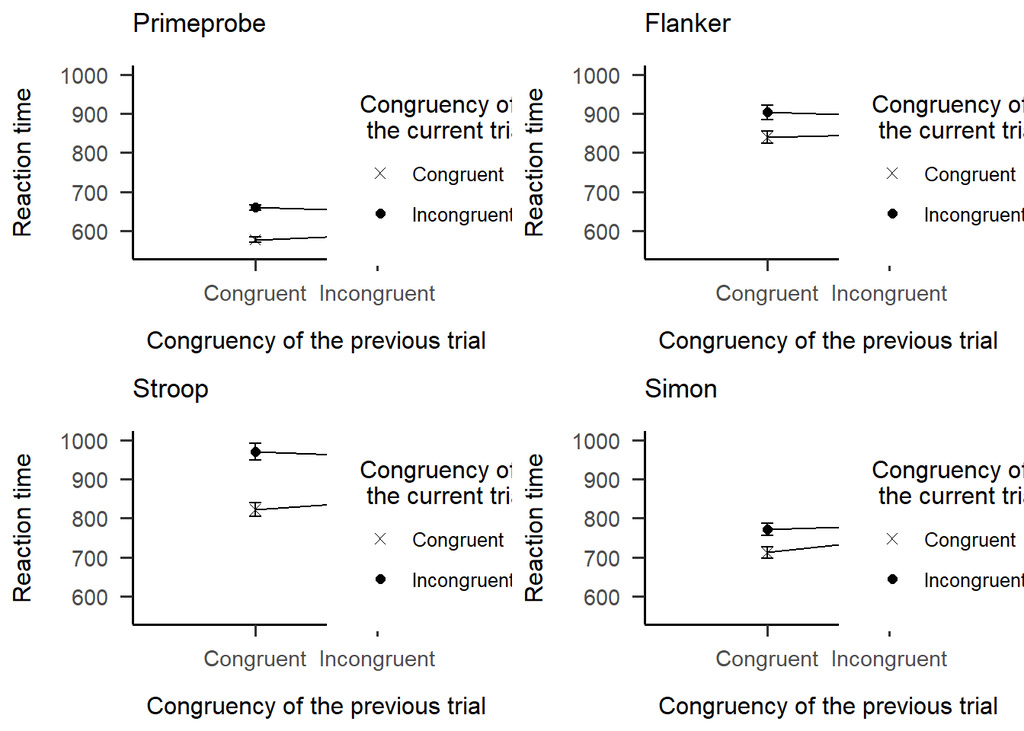

```r
cowplot::plot_grid(plotlist = processed$cse_plot_rt)
```

## Saving the figure

```r
ggsave("figures/weissman_replication_rt_cse.png", width = 14.4, height = 8, plot = last_plot())
```

## For the accuracy data

```r
processed <-
  processed %>%
  mutate(cse_plot_acc_data = map(acc_data,
                                . %>%
                                  mutate(isPrevCongruent = case_when(isPrevCongruent ==  0L ~ "Incongruent",
                                                                     isPrevCongruent ==  1L ~ "Congruent"),
                                         isCongruent = case_when(isCongruent ==  0L ~ "Incongruent",
                                                                 isCongruent ==  1L ~ "Congruent")) %>%
                                  group_by(participant_id, isPrevCongruent, isCongruent) %>%
                                  summarise(participant_mean_acc = mean(isCorrect, na.rm = T)) %>%
                                  group_by(isPrevCongruent, isCongruent) %>%
                                  summarise(N = n(),
                                            mean_acc = mean(participant_mean_acc, na.rm = T),
                                            sd_acc = sd(participant_mean_acc, na.rm = T),
                                            se_acc = sd_acc / sqrt(N))),
         cse_plot_acc = map2(cse_plot_acc_data, task,
                           ~ ggplot(.x, aes(x = isPrevCongruent, y = mean_acc, shape = isCongruent, group = isCongruent)) +
                             geom_path() +
                             geom_point(size = 2) +
                             geom_errorbar(aes(ymin = mean_acc - se_acc, ymax = mean_acc + se_acc), width=.1) +
                             scale_shape_manual(values=c(4, 16)) +
                             scale_y_continuous(limits = c(0.93, 1)) +
                             scale_x_discrete(expand=c(1, 0)) +
                             ggtitle(stringr::str_to_title(.y)) +
                             xlab("Congruency of the previous trial")+
                             ylab("Accuracy") +
                             guides(shape = guide_legend(title="Congruency of \n the current trial")) +
                             papaja::theme_apa() +
                             theme(legend.position = c(0.85, 0.5),
                                   axis.line = element_line(color = "black"))))
```

## Creating figure for the paper

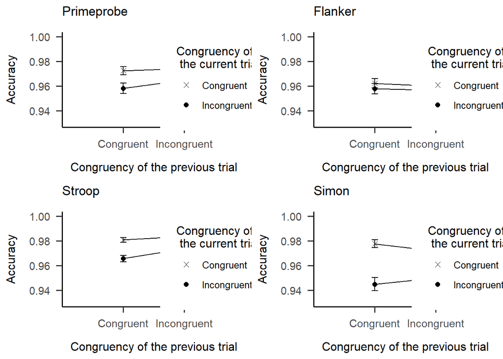

```r
cowplot::plot_grid(plotlist = processed$cse_plot_acc)
```

## Saving the figure

```r
ggsave("figures/weissman_replication_acc_cse.png", width = 14.4, height = 8, plot = last_plot())
```

## For the exploratory accuracy data

```r
processed <-
  processed %>%
  mutate(cse_plot_acc_exp_data = map(acc_exp_data,
                                . %>%
                                  mutate(isPrevCongruent = case_when(isPrevCongruent ==  0L ~ "Incongruent",
                                                                     isPrevCongruent ==  1L ~ "Congruent"),
                                         isCongruent = case_when(isCongruent ==  0L ~ "Incongruent",
                                                                 isCongruent ==  1L ~ "Congruent")) %>%
                                  group_by(participant_id, isPrevCongruent, isCongruent) %>%
                                  summarise(participant_mean_acc = mean(isCorrect, na.rm = T)) %>%
                                  group_by(isPrevCongruent, isCongruent) %>%
                                  summarise(N = n(),
                                            mean_acc = mean(participant_mean_acc, na.rm = T),
                                            sd_acc = sd(participant_mean_acc, na.rm = T),
                                            se_acc = sd_acc / sqrt(N))),
         cse_plot_acc_exp = map2(cse_plot_acc_exp_data, task,
                           ~ ggplot(.x, aes(x = isPrevCongruent, y = mean_acc, shape = isCongruent, group = isCongruent)) +
                             geom_path() +
                             geom_point(size = 2) +
                             geom_errorbar(aes(ymin = mean_acc - se_acc, ymax = mean_acc + se_acc), width=.1) +
                             scale_shape_manual(values=c(4, 16)) +
                             scale_y_continuous(limits = c(0.93, 1)) +
                             scale_x_discrete(expand=c(1, 0)) +
                             ggtitle(stringr::str_to_title(.y)) +
                             xlab("Congruency of the previous trial")+
                             ylab("Accuracy") +
                             guides(shape = guide_legend(title="Congruency of \n the current trial")) +
                             papaja::theme_apa() +
                             theme(legend.position = c(0.85, 0.5),
                                   axis.line = element_line(color = "black"))))
```

## Creating figure for the paper

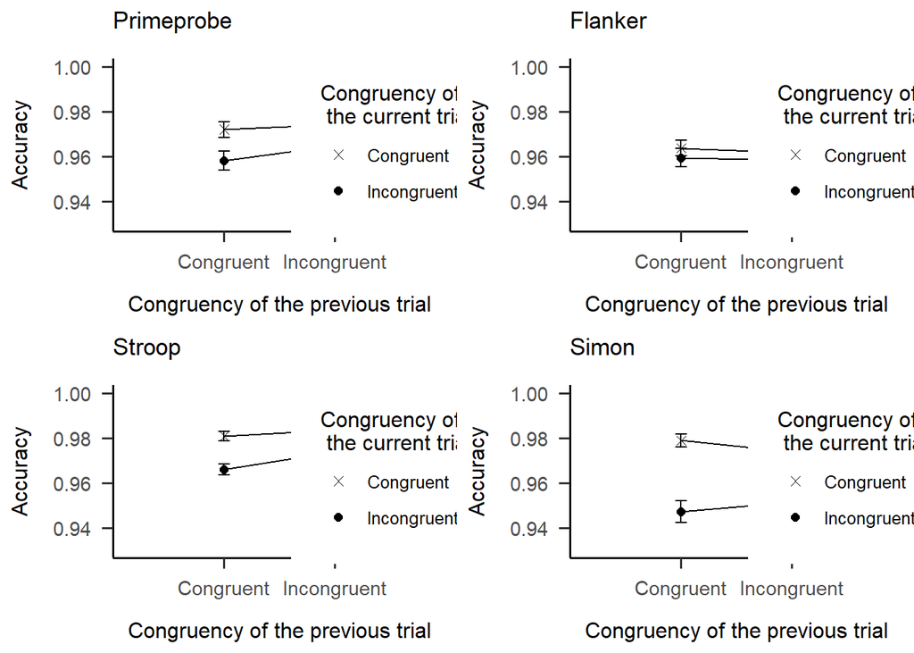

```r
cowplot::plot_grid(plotlist = processed$cse_plot_acc_exp)
```

## Saving the figure

```r
ggsave("figures/weissman_replication_acc_exp_cse.png", width = 14.4, height = 8, plot = last_plot())
```

# Reaction time analyis

## I. analysis: Testing whether the CSE was present in the different tasks

### Preprocessing data

We are calculating mean reaction time for the analysis for each participant in each condition for each task.

```r
processed <-
  processed %>%
  mutate(rt_data = map(rt_data,
                       . %>%
                         group_by(participant_id, isCongruent, isPrevCongruent) %>%
                         summarise(rtConditionalMean = mean(rt, na.rm = T)) %>%
                         ungroup() %>%
                         mutate(isCongruent = as.factor(isCongruent),
                                isPrevCongruent = as.factor(isPrevCongruent),
                                participant_id = as.factor(participant_id))))
```

We are calculating the main congruency effect of the current (n) trial, the main congruency effect of the previous trial (n-1) and the interaction effect (CSE) between them for each participant.

```r
processed <-
  processed %>%
  mutate(rt_effect_data = map(rt_data,
                              . %>%
                                ungroup() %>%
                                mutate(condition = case_when(isPrevCongruent == 0L & isCongruent == 0L ~ "ii",
                                                             isPrevCongruent == 0L & isCongruent == 1L ~ "ic",
                                                             isPrevCongruent == 1L & isCongruent == 0L ~ "ci",
                                                             isPrevCongruent == 1L & isCongruent == 1L ~ "cc",
                                                             TRUE ~ NA_character_)) %>%
                                select(-isPrevCongruent, -isCongruent) %>%
                                spread(key = condition, value = rtConditionalMean) %>%
                                mutate(congruencyEffect = ((ci + ii) / 2) - ((cc + ic) / 2),
                                       prevCongruencyEffect = ((ci + cc) / 2) - ((ii + ic) / 2),
                                       cseEffect = (ci - cc) - (ii - ic))))
```

### Running the analysis

We are running a 2 × 2 repeated-measures ANOVA per task with mean RT as dependent variable. The two factors of the ANOVA are Previous Trial Congruency (congruent, incongruent) and Current Trial Congruency (congruent, incongruent).

```r
processed <-
  processed %>%
  mutate(anova_rt = map(rt_data,
                        ~ aov(rtConditionalMean ~ isCongruent * isPrevCongruent + Error(participant_id / (isCongruent * isPrevCongruent)), data = .x)))

# Print results with names
processed$anova_rt %>%
  set_names(., processed$task) %>%
  map(., summary)
```

```
## $primeprobe
##
## Error: participant_id
##            Df  Sum Sq Mean Sq F value
## Residuals 114 2650017   23246
##           Pr(>F)
## Residuals
##
## Error: participant_id:isCongruent
##              Df Sum Sq Mean Sq F value
## isCongruent   1 579442  579442   689.6
## Residuals   114  95795     840
##             Pr(>F)
## isCongruent <2e-16 ***
## Residuals
## ---
## Signif. codes:
##   0 '***' 0.001 '**' 0.01 '*' 0.05 '.'
##   0.1 ' ' 1
##
## Error: participant_id:isPrevCongruent
##                  Df Sum Sq Mean Sq
## isPrevCongruent   1    598   598.1
## Residuals       114  24361   213.7
##                 F value Pr(>F)
## isPrevCongruent   2.799 0.0971 .
## Residuals
## ---
## Signif. codes:
##   0 '***' 0.001 '**' 0.01 '*' 0.05 '.'
##   0.1 ' ' 1
##
## Error: participant_id:isCongruent:isPrevCongruent
##                              Df Sum Sq
## isCongruent:isPrevCongruent   1  15019
## Residuals                   114  22622
##                             Mean Sq
## isCongruent:isPrevCongruent   15019
## Residuals                       198
##                             F value
```

[output cut: 136 more lines]

```
## isCongruent:isPrevCongruent   1  17608
## Residuals                   118 195228
##                             Mean Sq
## isCongruent:isPrevCongruent   17608
## Residuals                      1654
##                             F value
## isCongruent:isPrevCongruent   10.64
## Residuals
##                              Pr(>F)
## isCongruent:isPrevCongruent 0.00145 **
## Residuals
## ---
## Signif. codes:
##   0 '***' 0.001 '**' 0.01 '*' 0.05 '.'
##   0.1 ' ' 1
```

We are calculating the partial eta square as an effect size estimate for the ANOVA.

```r
processed <-
  processed %>%
  mutate(anova_rt_eta = map(anova_rt,
                            ~ eta_sq(.x, partial = TRUE)))

# Print results with names
processed$anova_rt_eta %>%
  set_names(., processed$task)
```

```
## $primeprobe
##                                         term
## 1                 participant_id:isCongruent
## 2 participant_id:isCongruent:isPrevCongruent
## 3             participant_id:isPrevCongruent
##                 partial.etasq
## 1                 isCongruent
## 2 isCongruent:isPrevCongruent
## 3             isPrevCongruent
##   Eta_Sq_partial
## 1          0.858
## 2          0.399
## 3          0.024
##
## $flanker
##                                         term
## 1                 participant_id:isCongruent
## 2 participant_id:isCongruent:isPrevCongruent
## 3             participant_id:isPrevCongruent
##                 partial.etasq
## 1                 isCongruent
## 2 isCongruent:isPrevCongruent
## 3             isPrevCongruent
##   Eta_Sq_partial
## 1          0.492
## 2          0.035
## 3          0.001
##
## $stroop
##                                         term
## 1                 participant_id:isCongruent
## 2 participant_id:isCongruent:isPrevCongruent
## 3             participant_id:isPrevCongruent
##                 partial.etasq
## 1                 isCongruent
## 2 isCongruent:isPrevCongruent
## 3             isPrevCongruent
##   Eta_Sq_partial
## 1          0.616
## 2          0.089
## 3          0.008
##
## $simon
##                                         term
## 1                 participant_id:isCongruent
## 2 participant_id:isCongruent:isPrevCongruent
## 3             participant_id:isPrevCongruent
##                 partial.etasq
## 1                 isCongruent
## 2 isCongruent:isPrevCongruent
## 3             isPrevCongruent
##   Eta_Sq_partial
## 1          0.550
## 2          0.083
## 3          0.248
```

### Calculating Bayes factors

#### Preprocessing data for the Bayes factor analysis

We are substracting the F values for each effect (main congruency effect of current trial, main congruency effect of previous trial and interaction effect) from the ANOVA.

```r
processed <-
  processed %>%
  mutate(anova_rt_f = map(anova_rt,
                          . %>%
                            broom::tidy() %>%
                            select(term, statistic) %>%
                            transmute(term = case_when(term == "isCongruent" ~ "mainEffectIsCongruent",
                                                       term == "isPrevCongruent" ~ "mainEffectIsPrevCongruent",
                                                       term == "isCongruent:isPrevCongruent" ~ "interactionEffect",
                                                       term == "Residuals" ~ term),
                                      fValue = statistic) %>%
                            filter(!is.na(fValue))))
```

We are calculating the mean effects (main congruency effect of current trial, main congruency effect of previous trial and interaction effect) for each task.

```r
processed <-
  processed %>%
  mutate(anova_rt_raw_effect = map(rt_effect_data,
                                   . %>%
                                     summarise(mainEffectIsCongruent = mean(congruencyEffect, na.rm = T),
                                               mainEffectIsPrevCongruent = mean(prevCongruencyEffect, na.rm = T),
                                               interactionEffect = mean(cseEffect, na.rm = T),
                                               nParticipant = n()) %>%
                                     gather(key = "term", value = "rawEffect", -nParticipant)))
#We can create a table with the magnitude of the CSE across tasks here, right?
```

We are adding the calucalted F-values for each effect to the calculated mean effects.

```r
processed <-
  processed %>%
  mutate(anova_rt_raw_effect = map2(anova_rt_raw_effect, anova_rt_f,
                                    ~ inner_join(.x, .y, by = "term")))
```

Calculating the SEs.

```r
processed <-
  processed %>%
  mutate(anova_rt_raw_effect = map(anova_rt_raw_effect,
                                   . %>%
                                     mutate(se = rawEffect / sqrt(fValue))))
```

Preprocessing effect sizes that Weissman et al. (2014) found for the H1 model of the Bayes factor analysis.

```r
original_rt_effect <-
  original %>%
  filter(measure == "rt") %>%
  select(task, congruency, cse) %>%
  gather(key = "term", value = "originalRawEffect", -task) %>%
  mutate(term = case_when(term == "congruency" ~ "mainEffectIsCongruent",
                          term == "cse" ~ "interactionEffect")) %>%
  group_by(task) %>%
  nest() %>%
  rename(original_effect_reaction_time = data)
```

Joining the effect sizes of the replicated study with the effect sizes of the current study.

```r
processed <-
  processed %>%
  mutate(task = as.character(task)) %>% # vector needs to be character class (instead of a list) for joining
  left_join(., original_rt_effect, by = "task") %>%
  mutate(anova_rt_bf_effect = map2(anova_rt_raw_effect, original_effect_reaction_time,
                              ~ left_join(.x, .y, by = "term")))
```

#### Calculating the Bayes factor

##### For the interaction effect

A half-normal distribution is used with a mode of 0 and a SD equal to the half of the congruency effect (in ms) for the particular task in the original data set by Weissman et al. (2014) to model the prediction of the interaction effect.

```r
processed <-
  processed %>%
  mutate(bf_interaction_rt = map(anova_rt_bf_effect,
                                 ~ Bf(sd = .x$se[3],
                                      obtained = .x$rawEffect[3],
                                      dfdata = .x$nParticipant[1] - 1,
                                      meanoftheory = 0,
                                      sdtheory = .x$originalRawEffect[1] / 2,
                                      dftheory = 10^10,
                                      tail = 1)))

# Print results with names
processed$bf_interaction_rt %>%
  set_names(., processed$task)
```

```
## $primeprobe
## [1] 612293739073
##
## $flanker
## [1] 4.27228
##
## $stroop
## [1] 135.3993
##
## $simon
## [1] 63.51217
```

###### Finding the robustness region for the interaction effect

```r
# Finding the lower boundary of the robustness region
## Primeprobe
primeprobe_rt <- processed$anova_rt_bf_effect[[1]]

Bf(sd = primeprobe_rt$se[3],
   obtained = primeprobe_rt$rawEffect[3],
   dfdata = primeprobe_rt$nParticipant[1] - 1,
   meanoftheory = 0,
   sdtheory = 0.54,
   dftheory = 10^10,
   tail = 1)
```

```
## [1] 3.081314
```

```r
## Flanker
flanker_rt <- processed$anova_rt_bf_effect[[2]]

Bf(sd = flanker_rt$se[3],
   obtained = flanker_rt$rawEffect[3],
   dfdata = flanker_rt$nParticipant[1] - 1,
   meanoftheory = 0,
   sdtheory = 5.3,
   dftheory = 10^10,
   tail = 1)
```

```
## [1] 3.015802
```

```r
## Stroop
stroop_rt <- processed$anova_rt_bf_effect[[3]]

Bf(sd = stroop_rt$se[3],
   obtained = stroop_rt$rawEffect[3],
   dfdata = stroop_rt$nParticipant[1] - 1,
   meanoftheory = 0,
   sdtheory = 3.3,
   dftheory = 10^10,
   tail = 1)
```

```
## [1] 3.029047
```

```r
## Simon
simon_rt <- processed$anova_rt_bf_effect[[4]]

Bf(sd = simon_rt$se[3],
   obtained = simon_rt$rawEffect[3],
   dfdata = simon_rt$nParticipant[1] - 1,
   meanoftheory = 0,
   sdtheory = 2.9,
   dftheory = 10^10,
   tail = 1)
```

```
## [1] 3.017997
```

```r
# Finding the upper boundary of the robustness region
## Primeprobe
Bf(sd = primeprobe_rt$se[3],
   obtained = primeprobe_rt$rawEffect[3],
   dfdata = primeprobe_rt$nParticipant[1] - 1,
   meanoftheory = 0,
   sdtheory = 8468,
   dftheory = 10^10,
   tail = 1)
```

```
## [1] 3.060813
```

```r
## Flanker
Bf(sd = flanker_rt$se[3],
   obtained = flanker_rt$rawEffect[3],
   dfdata = flanker_rt$nParticipant[1] - 1,
   meanoftheory = 0,
   sdtheory = 42,
   dftheory = 10^10,
   tail = 1)
```

```
## [1] 3.088457
```

```r
## Stroop
Bf(sd = stroop_rt$se[3],
   obtained = stroop_rt$rawEffect[3],
   dfdata = stroop_rt$nParticipant[1] - 1,
   meanoftheory = 0,
   sdtheory = 2650,
   dftheory = 10^10,
   tail = 1)
```

```
## [1] 3.095619
```

```r
## Simon
Bf(sd = simon_rt$se[3],
   obtained = simon_rt$rawEffect[3],
   dfdata = simon_rt$nParticipant[1] - 1,
   meanoftheory = 0,
   sdtheory = 840,
   dftheory = 10^10,
   tail = 1)
```

```
## [1] 3.032022
```

##### For the main congruency effect of the current trial

To test the congruency main effect, the SD of the H1 model is set to the congruency effect reported by Weissman et al. (2014) for the given task. The other settings stay the same.

```r
processed <-
  processed %>%
  mutate(bf_congruency_rt = map(anova_rt_bf_effect,
                                ~ Bf(sd = .x$se[1],
                                     obtained = .x$rawEffect[1],
                                     dfdata = .x$nParticipant[1] - 1,
                                     meanoftheory = 0,
                                     sdtheory = .x$originalRawEffect[1],
                                     dftheory = 10^10,
                                     tail = 1)))

# Print results with names
processed$bf_congruency_rt %>%
  set_names(., processed$task)
```

```
## $primeprobe
## [1] 2.695697e+47
##
## $flanker
## [1] 2.662816e+17
##
## $stroop
## [1] 7.473517e+25
##
## $simon
## [1] 4.364132e+19
```

```r
# Finding the lower boundary of the robustness region
## Primeprobe
Bf(sd = primeprobe_rt$se[1],
   obtained = primeprobe_rt$rawEffect[1],
   dfdata = primeprobe_rt$nParticipant[1] - 1,
   meanoftheory = 0,
   sdtheory = 0.76,
   dftheory = 10^10,
   tail = 1)
```

```
## [1] 3.012606
```

```r
## Flanker
Bf(sd = flanker_rt$se[1],
   obtained = flanker_rt$rawEffect[1],
   dfdata = flanker_rt$nParticipant[1] - 1,
   meanoftheory = 0,
   sdtheory = 0.99,
   dftheory = 10^10,
   tail = 1)
```

```
## [1] 3.095885
```

```r
## Stroop
Bf(sd = stroop_rt$se[1],
   obtained = stroop_rt$rawEffect[1],
   dfdata = stroop_rt$nParticipant[1] - 1,
   meanoftheory = 0,
   sdtheory = 1.75,
   dftheory = 10^10,
   tail = 1)
```

```
## [1] 3.010438
```

```r
## Simon
Bf(sd = simon_rt$se[1],
   obtained = simon_rt$rawEffect[1],
   dfdata = simon_rt$nParticipant[1] - 1,
   meanoftheory = 0,
   sdtheory = 0.76,
   dftheory = 10^10,
   tail = 1)
```

```
## [1] 3.028493
```

```r
# Finding the upper boundary of the robustness region
## Primeprobe
Bf(sd = primeprobe_rt$se[1],
   obtained = primeprobe_rt$rawEffect[1],
   dfdata = primeprobe_rt$nParticipant[1] - 1,
   meanoftheory = 0,
   sdtheory = 27462,
   dftheory = 10^10,
   tail = 1)
```

```
## [1] 3.025888
```

```r
## Flanker
Bf(sd = flanker_rt$se[1],
   obtained = flanker_rt$rawEffect[1],
   dfdata = flanker_rt$nParticipant[1] - 1,
   meanoftheory = 0,
   sdtheory = 21272,
   dftheory = 10^10,
   tail = 1)
```

```
## [1] 3.014408
```

```r
## Stroop
Bf(sd = stroop_rt$se[1],
   obtained = stroop_rt$rawEffect[1],
   dfdata = stroop_rt$nParticipant[1] - 1,
   meanoftheory = 0,
   sdtheory = 50778,
   dftheory = 10^10,
   tail = 1)
```

```
## [1] 3.016327
```

```r
## Simon
Bf(sd = simon_rt$se[1],
   obtained = simon_rt$rawEffect[1],
   dfdata = simon_rt$nParticipant[1] - 1,
   meanoftheory = 0,
   sdtheory = 17712,
   dftheory = 10^10,
   tail = 1)
```

```
## [1] 3.057088
```

### Follow up simple effects analysis

#### Running the analysis

If the Bayes factor is greater than the preset threshold of B = 3 for the interaction effect in a given task we run a simple effects analyses, contrasting current-congruent congruent (cC) and current-incongruent congruent (iC) trials.

```r
processed <-
  processed %>%
  mutate(cong_post_rt = map(rt_data,
                            . %>%
                              filter(isCongruent == 1)),
         cong_post_rt_test = map2(cong_post_rt, task,
                                  ~ aov(rtConditionalMean ~ isPrevCongruent + Error(participant_id / isPrevCongruent), data = .x)))

# Print results with names
processed$cong_post_rt_test %>%
  set_names(., processed$task) %>%
  map(., summary)
```

```
## $primeprobe
##
## Error: participant_id
##            Df  Sum Sq Mean Sq F value
## Residuals 114 1347754   11822
##           Pr(>F)
## Residuals
##
## Error: participant_id:isPrevCongruent
##                  Df Sum Sq Mean Sq
## isPrevCongruent   1  10806   10806
## Residuals       114  22191     195
##                 F value   Pr(>F)
## isPrevCongruent   55.51 1.93e-11 ***
## Residuals
## ---
## Signif. codes:
##   0 '***' 0.001 '**' 0.01 '*' 0.05 '.'
##   0.1 ' ' 1
##
## $flanker
##
## Error: participant_id
##            Df  Sum Sq Mean Sq F value
## Residuals 124 8265397   66656
##           Pr(>F)
## Residuals
##
## Error: participant_id:isPrevCongruent
##                  Df Sum Sq Mean Sq
## isPrevCongruent   1   3102    3102
## Residuals       124 202143    1630
##                 F value Pr(>F)
## isPrevCongruent   1.903   0.17
## Residuals
##
## $stroop
##
## Error: participant_id
##            Df   Sum Sq Mean Sq F value
```

[output cut: 20 more lines]

```
## Residuals 118 6070513   51445
##           Pr(>F)
## Residuals
##
## Error: participant_id:isPrevCongruent
##                  Df Sum Sq Mean Sq
## isPrevCongruent   1  70378   70378
## Residuals       118 167531    1420
##                 F value   Pr(>F)
## isPrevCongruent   49.57 1.36e-10 ***
## Residuals
## ---
## Signif. codes:
##   0 '***' 0.001 '**' 0.01 '*' 0.05 '.'
##   0.1 ' ' 1
```

```r
processed <-
  processed %>%
  mutate(incong_post_rt = map(rt_data,
                            . %>%
                              filter(isCongruent == 0)),
         incong_post_rt_test = map2(incong_post_rt, task,
                                  ~ aov(rtConditionalMean ~ isPrevCongruent + Error(participant_id / isPrevCongruent), data = .x)))

# Print results with names
processed$incong_post_rt_test %>%
  set_names(., processed$task) %>%
  map(., summary)
```

```
## $primeprobe
##
## Error: participant_id
##            Df  Sum Sq Mean Sq F value
## Residuals 114 1398059   12264
##           Pr(>F)
## Residuals
##
## Error: participant_id:isPrevCongruent
##                  Df Sum Sq Mean Sq
## isPrevCongruent   1   4812    4812
## Residuals       114  24792     217
##                 F value   Pr(>F)
## isPrevCongruent   22.12 7.22e-06 ***
## Residuals
## ---
## Signif. codes:
##   0 '***' 0.001 '**' 0.01 '*' 0.05 '.'
##   0.1 ' ' 1
##
## $flanker
##
## Error: participant_id
##            Df  Sum Sq Mean Sq F value
## Residuals 124 9788099   78936
##           Pr(>F)
## Residuals
##
## Error: participant_id:isPrevCongruent
##                  Df Sum Sq Mean Sq
## isPrevCongruent   1   5199    5199
## Residuals       124 221314    1785
##                 F value Pr(>F)
## isPrevCongruent   2.913 0.0904 .
## Residuals
## ---
## Signif. codes:
##   0 '***' 0.001 '**' 0.01 '*' 0.05 '.'
##   0.1 ' ' 1
##
```

[output cut: 24 more lines]

```
## Residuals 118 6374447   54021
##           Pr(>F)
## Residuals
##
## Error: participant_id:isPrevCongruent
##                  Df Sum Sq Mean Sq
## isPrevCongruent   1   6026    6026
## Residuals       118 205555    1742
##                 F value Pr(>F)
## isPrevCongruent   3.459 0.0654 .
## Residuals
## ---
## Signif. codes:
##   0 '***' 0.001 '**' 0.01 '*' 0.05 '.'
##   0.1 ' ' 1
```

#### Brute force method for follow ups - setting up BF calculations

```r
primeprobe <- processed$rt_effect_data[[1]]
flanker <- processed$rt_effect_data[[2]]
stroop <- processed$rt_effect_data[[3]]
simon <- processed$rt_effect_data[[4]]

current_cong_pp <-
  t.test(primeprobe$ic, primeprobe$cc, paired = TRUE) %>%
  broom::tidy()
current_cong_fl <-
  t.test(flanker$ic, flanker$cc, paired = TRUE) %>%
  broom::tidy()
current_cong_str <-
  t.test(stroop$ic, stroop$cc, paired = TRUE) %>%
  broom::tidy()
current_cong_sim <-
  t.test(simon$ic, simon$cc, paired = TRUE) %>%
  broom::tidy()

current_inc_pp <-
  t.test(primeprobe$ci, primeprobe$ii, paired = TRUE) %>%
  broom::tidy()
current_inc_fl <-
  t.test(flanker$ci, flanker$ii, paired = TRUE) %>%
  broom::tidy()
current_inc_str <-
  t.test(stroop$ci, stroop$ii, paired = TRUE) %>%
  broom::tidy()
current_inc_sim <-
  t.test(simon$ci, simon$ii, paired = TRUE) %>%
  broom::tidy()
```

#### Calculating the Bayes factor for the follow up analysis

The prior H1 model is a half-normal distribution with a mode of 0 and an SD equal to half of the CSE estimate for that given task, i.e., the originally reported congruency effect divided by four.

##### Current congruent follow up analysis

```r
Bf(sd = current_cong_pp$estimate / current_cong_pp$statistic,
   obtained = current_cong_pp$estimate,
   dfdata = current_cong_pp$parameter,
   meanoftheory = 0,
   sdtheory = processed$anova_rt_bf_effect[[1]]$originalRawEffect[1] / 4,
   dftheory = 10^10,
   tail = 1)
```

```
## mean of the differences
##              1223485506
```

```r
Bf(sd = current_cong_fl$estimate / current_cong_fl$statistic,
   obtained = current_cong_fl$estimate,
   dfdata = current_cong_fl$parameter,
   meanoftheory = 0,
   sdtheory = processed$anova_rt_bf_effect[[2]]$originalRawEffect[1] / 4,
   dftheory = 10^10,
   tail = 1)
```

```
## mean of the differences
##                1.472317
```

```r
Bf(sd = current_cong_str$estimate / current_cong_str$statistic,
   obtained = current_cong_str$estimate,
   dfdata = current_cong_str$parameter,
   meanoftheory = 0,
   sdtheory = processed$anova_rt_bf_effect[[3]]$originalRawEffect[1] / 4,
   dftheory = 10^10,
   tail = 1)
```

```
## mean of the differences
##                77.28731
```

```r
Bf(sd = current_cong_sim$estimate / current_cong_sim$statistic,
   obtained = current_cong_sim$estimate,
   dfdata = current_cong_sim$parameter,
   meanoftheory = 0,
   sdtheory = processed$anova_rt_bf_effect[[4]]$originalRawEffect[1] / 4,
   dftheory = 10^10,
   tail = 1)
```

```
## mean of the differences
##                18886695
```

###### Finding the robustness region for the current congruent follow up analysis

```r
# Finding the lower boundary of the robustness region
Bf(sd = current_cong_pp$estimate / current_cong_pp$statistic,
   obtained = current_cong_pp$estimate,
   dfdata = current_cong_pp$parameter,
   meanoftheory = 0,
   sdtheory = 0.39,
   dftheory = 10^10,
   tail = 1)
```

```
## mean of the differences
##                3.009497
```

```r
Bf(sd = current_cong_fl$estimate / current_cong_fl$statistic,
   obtained = current_cong_fl$estimate,
   dfdata = current_cong_fl$parameter,
   meanoftheory = 0,
   sdtheory = processed$anova_rt_bf_effect[[2]]$originalRawEffect[1] / 4, #this was inconclusive so will not be reported in detail
   dftheory = 10^10,
   tail = 1)
```

```
## mean of the differences
##                1.472317
```

```r
Bf(sd = current_cong_str$estimate / current_cong_str$statistic,
   obtained = current_cong_str$estimate,
   dfdata = current_cong_str$parameter,
   meanoftheory = 0,
   sdtheory = 2.45,
   dftheory = 10^10,
   tail = 1)
```

```
## mean of the differences
##                3.068354
```

```r
Bf(sd = current_cong_sim$estimate / current_cong_sim$statistic,
   obtained = current_cong_sim$estimate,
   dfdata = current_cong_sim$parameter,
   meanoftheory = 0,
   sdtheory = 1.05,
   dftheory = 10^10,
   tail = 1)
```

```
## mean of the differences
##                3.004091
```

```r
# Finding the upper boundary of the robustness region
Bf(sd = current_cong_pp$estimate / current_cong_pp$statistic,
   obtained = current_cong_pp$estimate,
   dfdata = current_cong_pp$parameter,
   meanoftheory = 0,
   sdtheory = 4980,
   dftheory = 10^10,
   tail = 1)
```

```
## mean of the differences
##                3.084465
```

```r
Bf(sd = current_cong_fl$estimate / current_cong_fl$statistic,
   obtained = current_cong_fl$estimate,
   dfdata = current_cong_fl$parameter,
   meanoftheory = 0,
   sdtheory = processed$anova_rt_bf_effect[[2]]$originalRawEffect[1] / 4, #this was inconclusive
   dftheory = 10^10,
   tail = 1)
```

```
## mean of the differences
##                1.472317
```

```r
Bf(sd = current_cong_str$estimate / current_cong_str$statistic,
   obtained = current_cong_str$estimate,
   dfdata = current_cong_str$parameter,
   meanoftheory = 0,
   sdtheory = 910,
   dftheory = 10^10,
   tail = 1)
```

```
## mean of the differences
##                3.028252
```

```r
Bf(sd = current_cong_sim$estimate / current_cong_sim$statistic,
   obtained = current_cong_sim$estimate,
   dfdata = current_cong_sim$parameter,
   meanoftheory = 0,
   sdtheory = 12395,
   dftheory = 10^10,
   tail = 1)
```

```
## mean of the differences
##                3.040349
```

##### Current incongruent follow up analysis

```r
Bf(sd = current_inc_pp$estimate / current_inc_pp$statistic,
   obtained = current_inc_pp$estimate,
   dfdata = current_inc_pp$parameter,
   meanoftheory = 0,
   sdtheory = processed$anova_rt_bf_effect[[1]]$originalRawEffect[1] / 4,
   dftheory = 10^10,
   tail = 1)
```

```
## mean of the differences
##                5020.027
```

```r
Bf(sd = current_inc_fl$estimate / current_inc_fl$statistic,
   obtained = current_inc_fl$estimate,
   dfdata = current_inc_fl$parameter,
   meanoftheory = 0,
   sdtheory = processed$anova_rt_bf_effect[[2]]$originalRawEffect[1] / 4,
   dftheory = 10^10,
   tail = 1)
```

```
## mean of the differences
##                2.438911
```

```r
Bf(sd = current_inc_str$estimate / current_inc_str$statistic,
   obtained = current_inc_str$estimate,
   dfdata = current_inc_str$parameter,
   meanoftheory = 0,
   sdtheory = processed$anova_rt_bf_effect[[3]]$originalRawEffect[1] / 4,
   dftheory = 10^10,
   tail = 1)
```

```
## mean of the differences
##                2.074206
```

```r
Bf(sd = current_inc_sim$estimate / current_inc_sim$statistic,
   obtained = current_inc_sim$estimate,
   dfdata = current_inc_sim$parameter,
   meanoftheory = 0,
   sdtheory = processed$anova_rt_bf_effect[[4]]$originalRawEffect[1] / 4,
   dftheory = 10^10,
   tail = 1)
```

```
## mean of the differences
##               0.1676836
```

###### Finding the robustness region for the current incongruent follow up analysis

```r
# Finding the lower boundary of the robustness region
Bf(sd = current_inc_pp$estimate / current_inc_pp$statistic,
   obtained = current_inc_pp$estimate,
   dfdata = current_inc_pp$parameter,
   meanoftheory = 0,
   sdtheory = 0.55,
   dftheory = 10^10,
   tail = 1)
```

```
## mean of the differences
##                3.087881
```

```r
Bf(sd = current_inc_fl$estimate / current_inc_fl$statistic,
   obtained = current_inc_fl$estimate,
   dfdata = current_inc_fl$parameter,
   meanoftheory = 0,
   sdtheory = processed$anova_rt_bf_effect[[2]]$originalRawEffect[1] / 4, #this was inconclusive
   dftheory = 10^10,
   tail = 1)
```

```
## mean of the differences
##                2.438911
```

```r
Bf(sd = current_inc_str$estimate / current_inc_str$statistic,
   obtained = current_inc_str$estimate,
   dfdata = current_inc_str$parameter,
   meanoftheory = 0,
   sdtheory = processed$anova_rt_bf_effect[[3]]$originalRawEffect[1] / 4, #this was inconclusive
   dftheory = 10^10,
   tail = 1)
```

```
## mean of the differences
##                2.074206
```

```r
Bf(sd = current_inc_sim$estimate / current_inc_sim$statistic,
   obtained = current_inc_sim$estimate,
   dfdata = current_inc_sim$parameter,
   meanoftheory = 0,
   sdtheory = 5.25,
   dftheory = 10^10,
   tail = 1)
```

```
## mean of the differences
##               0.3301822
```

```r
# Finding the upper boundary of the robustness region
Bf(sd = current_inc_pp$estimate / current_inc_pp$statistic,
   obtained = current_inc_pp$estimate,
   dfdata = current_inc_pp$parameter,
   meanoftheory = 0,
   sdtheory = 2880,
   dftheory = 10^10,
   tail = 1)
```

```
## mean of the differences
##                3.029023
```

```r
Bf(sd = current_inc_fl$estimate / current_inc_fl$statistic,
   obtained = current_inc_fl$estimate,
   dfdata = current_inc_fl$parameter,
   meanoftheory = 0,
   sdtheory = processed$anova_rt_bf_effect[[2]]$originalRawEffect[1] / 4, #this was inconclusive
   dftheory = 10^10,
   tail = 1)
```

```
## mean of the differences
##                2.438911
```

```r
Bf(sd = current_inc_str$estimate / current_inc_str$statistic,
   obtained = current_inc_str$estimate,
   dfdata = current_inc_str$parameter,
   meanoftheory = 0,
   sdtheory = processed$anova_rt_bf_effect[[3]]$originalRawEffect[1] / 4, #this was inconclusive
   dftheory = 10^10,
   tail = 1)
```

```
## mean of the differences
##                2.074206
```

```r
Bf(sd = current_inc_sim$estimate / current_inc_sim$statistic,
   obtained = current_inc_sim$estimate,
   dfdata = current_inc_sim$parameter,
   meanoftheory = 0,
   sdtheory = 5.25, #???
   dftheory = 10^10,
   tail = 1)
```

```
## mean of the differences
##               0.3301822
```

## II. analysis: Testing whether the size of the CSE varies across tasks

### Creating the datatable

We are combining the effects (main congruency effect of current trial, main congruency effect of previous trial and interaction effect) for each task (primeprobe, Flanker, Stroop, Simon) in one datatable.

```r
interaction_rt_data <-
  processed %>%
  select(task, rt_effect_data) %>%
  unnest(rt_effect_data) %>%
  mutate(task = as.factor(task))
```

### Testing the assumptions

We are testing the homogenity of variances.

```r
car::leveneTest(cseEffect ~ task, data = interaction_rt_data)
```

```
## Levene's Test for Homogeneity of Variance (center = median)
##        Df F value    Pr(>F)
## group   3  17.551 7.844e-11 ***
##       485
## ---
## Signif. codes:
##   0 '***' 0.001 '**' 0.01 '*' 0.05 '.'
##   0.1 ' ' 1
```

The assumption of homogenity of variances is violated. Therefore, we are running a Kruskal Wallis H test instead of an ANOVA.

### Running the analysis

We are running a Kruskal-Wallis H test with task (levels: Prime-Probe, Flanker, Stroop, Simon) as the single factor, and the CSE index as the dependent variable to examine if the size of the effect differs across tasks.

```r
kruskal.test(cseEffect ~ task, data = interaction_rt_data)
```

```
##
##  Kruskal-Wallis rank sum test
##
## data:  cseEffect by task
## Kruskal-Wallis chi-squared = 7.4612,
## df = 3, p-value = 0.05856
```

### Calculating pairwise comparisons

A Dunn’s test is used for pairwise comparisons.

```r
dunn_test <- DescTools::DunnTest(cseEffect ~ task, data = interaction_rt_data)

dunn_test
```

```
##
##  Dunn's test of multiple comparisons using rank sums : holm
##
##                    mean.rank.diff   pval
## primeprobe-flanker     33.4855652 0.3083
## simon-flanker          33.8193613 0.3083
## stroop-flanker         46.3083077 0.0534
## simon-primeprobe        0.3337961 1.0000
## stroop-primeprobe      12.8227425 1.0000
## stroop-simon           12.4889463 1.0000
##
## primeprobe-flanker
## simon-flanker
## stroop-flanker     .
## simon-primeprobe
## stroop-primeprobe
## stroop-simon
## ---
## Signif. codes:  0 '***' 0.001 '**' 0.01 '*' 0.05 '.' 0.1 ' ' 1
```

Creating a tidy datatable from the Dunn test output.

```r
dunn_test <-
  dunn_test[[1]] %>%
  as_tibble(rownames = "comparison") %>%
  janitor::clean_names()
```